# Data Exploration

Introduction: For this assignment, I analyzed a corpus of Early Modern political economy texts provided on Canvas. These documents were intentionally selected as part of a shared intellectual tradition, allowing for systematic comparison. After cleaning and normalizing the texts, I conducted an exploratory analysis using three approaches: TF–IDF to identify lexically distinctive terms, Pearson correlation to measure similarity between documents, and syntactic complexity measures to compare structural writing patterns across two selected texts. Together, these methods allowed me to examine how the texts relate to one another both in vocabulary use and grammatical structure.

```r
library(tidyverse)
library(tidytext)
library(stringr)
library(widyr)
```

```r
getwd()
```

```
## [1] "/Users/sejal/Documents/Text_As_Data/text_as_data"
```

```r
list.files("texts", full.names = TRUE)
```

```
##  [1] "texts/A06785.txt" "texts/A06786.txt" "texts/A06788.txt" "texts/A06789.txt"
##  [5] "texts/A06790.txt" "texts/A06791.txt" "texts/A07594.txt" "texts/A07886.txt"
##  [9] "texts/A32827.txt" "texts/A32828.txt" "texts/A32829.txt" "texts/A32830.txt"
## [13] "texts/A32833.txt" "texts/A32836.txt" "texts/A32837.txt" "texts/A32838.txt"
## [17] "texts/A32839.txt" "texts/A50763.txt" "texts/A51598.txt" "texts/A69858.txt"
## [21] "texts/A93819.txt" "texts/B14801.txt" "texts/wealth.txt"
```

```r
# read_file("texts/A06785.txt")
```

```r
files <- list.files("texts",
                    pattern = "\\.txt$",
                    full.names = TRUE)

corpus_raw <- tibble(
  doc_id = tools::file_path_sans_ext(basename(files)),
  text = map_chr(files, read_file)
)

print(corpus_raw)
```

```
## # A tibble: 23 × 2
##    doc_id text
##    <chr>  <chr>
##  1 A06785 "STrong imagination, nourished by opinion, may cause most men to supp…
##  2 A06786 "WHen Almighty God had created man, good and a sociable creature, who…
##  3 A06788 "A SENTENCE alleged without application to some purpose, is to handle…
##  4 A06789 "NATURAL Mother wit, did teach man, before Arts or Sciences were inve…
##  5 A06790 "APRIL having with his sweet showers moistened the drought of March, …
##  6 A06791 "PLato the Philosopher perceiving that equality would be the cause th…
##  7 A07594 "THE CIRCLE OF COMMERCE. The Prooeme. HERODOTVS in his CLIO, reportes…
##  8 A07886 "THe trade of Merchandise, is not only that laudable practice whereby…
##  9 A32827 "THE Prodigious increase of the Netherlanders in their Domestic and F…
## 10 A32828 "WHEN fallen Man was driven out of Paradise, the heavy Charge imposed…
## # ℹ 13 more rows
```

```r
# Count words that contain "ſ" before replacement
sum(str_detect(corpus_raw$text, "ſ"))
```

```
## [1] 1
```

Step 0: Normalization

In preparing the corpus for analysis, I adopted a minimal-intervention normalization strategy. The goal was to ensure lexical comparability across documents while preserving historically meaningful orthographic variation.

0.1) First, I replaced the Early Modern long S character (ſ) with the modern letter “s,” as required. Without this correction, words like “ſtate” and “state” would be counted as different words, which would distort the analysis.

0.2) Second, I converted all text to lowercase and removed extra spaces. Lowercasing ensures that words such as “State” and “state” are treated as the same word. Collapsing extra whitespace prevents formatting inconsistencies from interfering with tokenization.

I chose not to modernize spelling or standardize variations such as u/v or archaic spellings. While doing so might make the texts look more uniform, it could also erase meaningful stylistic or historical differences between authors. Since this assignment focuses on exploring patterns rather than rewriting the texts, I aimed to preserve the original language as much as possible.

```r
corpus_normalized <- corpus_raw %>%
  mutate(
    text = str_replace_all(text, "ſ", "s") %>%   # normalize long S
           str_replace_all("\\s+", " ") %>%     # collapse extra whitespace
           str_to_lower()                        # standardize case
  )

corpus_normalized
```

```
## # A tibble: 23 × 2
##    doc_id text
##    <chr>  <chr>
##  1 A06785 "strong imagination, nourished by opinion, may cause most men to supp…
##  2 A06786 "when almighty god had created man, good and a sociable creature, who…
##  3 A06788 "a sentence alleged without application to some purpose, is to handle…
##  4 A06789 "natural mother wit, did teach man, before arts or sciences were inve…
##  5 A06790 "april having with his sweet showers moistened the drought of march, …
##  6 A06791 "plato the philosopher perceiving that equality would be the cause th…
##  7 A07594 "the circle of commerce. the prooeme. herodotvs in his clio, reportes…
##  8 A07886 "the trade of merchandise, is not only that laudable practice whereby…
##  9 A32827 "the prodigious increase of the netherlanders in their domestic and f…
## 10 A32828 "when fallen man was driven out of paradise, the heavy charge imposed…
## # ℹ 13 more rows
```

During tokenization, I also removed punctuation, standalone numbers, common stopwords (like “the” and “and”), and tokens containing obvious OCR errors (such as ● symbols). These elements do not carry meaningful content for this type of analysis and would otherwise introduce noise.

Overall, I used a minimal cleaning approach: correcting only what was necessary for accurate comparison while preserving the integrity of the original texts.

```r
tokens_df <- corpus_normalized %>%
  unnest_tokens(word, text)
```

```r
tokens_df <- tokens_df %>%
  anti_join(stop_words, by = "word") %>%         # remove stopwords
  filter(!str_detect(word, "^[0-9]+$")) %>%      # remove numbers
  filter(!str_detect(word, "●"))                 # remove OCR artifacts

# tokens_df
```

```r
#Check document length balance
tokens_df %>%
  count(doc_id, sort = TRUE)
```

```
## # A tibble: 23 × 2
##    doc_id      n
##    <chr>   <int>
##  1 wealth 128044
##  2 A06786  82055
##  3 A32833  16132
##  4 A32827  16098
##  5 A07594  13311
##  6 A06785  12894
##  7 A06788   9968
##  8 A51598   9211
##  9 A06789   8587
## 10 B14801   8139
## # ℹ 13 more rows
```

```r
# Check most frequent words

tokens_df %>%
  count(word, sort = TRUE) %>%
  slice_max(n, n = 20)
```

```
## # A tibble: 21 × 2
##    word            n
##    <chr>       <int>
##  1 trade        3234
##  2 money        3224
##  3 price        2093
##  4 commodities  1967
##  5 time         1866
##  6 country      1684
##  7 exchange     1641
##  8 silver       1470
##  9 merchants    1391
## 10 people       1306
## # ℹ 11 more rows
```

```r
# Vocabulary size per document

tokens_df %>%
  group_by(doc_id) %>%
  summarise(unique_words = n_distinct(word))
```

```
## # A tibble: 23 × 2
##    doc_id unique_words
##    <chr>         <int>
##  1 A06785         3639
##  2 A06786        11193
##  3 A06788         2774
##  4 A06789         2707
##  5 A06790         2234
##  6 A06791         1556
##  7 A07594         4234
##  8 A07886         1534
##  9 A32827         3886
## 10 A32828         1053
## # ℹ 13 more rows
```

```r
# Check for any non-alphabetic tokens

tokens_df %>%
  filter(str_detect(word, "[^a-z]")) %>%
  count(word, sort = TRUE)
```

```
## # A tibble: 1,019 × 2
##    word           n
##    <chr>      <int>
##  1 merchant's   228
##  2 king's       149
##  3 majesty's    149
##  4 men's        117
##  5 man's        114
##  6 butcher’s     54
##  7 country's     40
##  8 england's     35
##  9 prince's      35
## 10 god's         33
## # ℹ 1,009 more rows
```

These are real words and carry meaning, not OCR errors.

APPROACH 1: TF - IDF I computed TF–IDF scores for each document to identify terms that are distinctive relative to the rest of the corpus. This allowed me to see what makes each text lexically unique while still operating within a shared vocabulary.

```r
# Step 1: Document feature matrix

dfm_counts <- tokens_df %>%
  count(doc_id, word, sort = TRUE)

dfm_counts
```

```
## # A tibble: 60,375 × 3
##    doc_id word         n
##    <chr>  <chr>    <int>
##  1 wealth price     1264
##  2 wealth country   1240
##  3 wealth labor     1011
##  4 wealth trade      970
##  5 wealth produce    945
##  6 wealth quantity   797
##  7 wealth people     777
##  8 wealth money      770
##  9 A06786 money      750
## 10 wealth land       720
## # ℹ 60,365 more rows
```

```r
# Step 2: Compute TF–IDF weights

tf_idf_data <- dfm_counts %>%
  bind_tf_idf(word, doc_id, n) %>%
  arrange(desc(tf_idf))

tf_idf_data
```

```
## # A tibble: 60,375 × 6
##    doc_id word         n      tf   idf tf_idf
##    <chr>  <chr>    <int>   <dbl> <dbl>  <dbl>
##  1 A93819 key         29 0.0294   1.75 0.0513
##  2 A93819 stairs      23 0.0233   1.75 0.0407
##  3 A07594 haue       163 0.0122   2.44 0.0299
##  4 A93819 lion        17 0.0172   1.53 0.0263
##  5 B14801 haue        86 0.0106   2.44 0.0258
##  6 A32838 surrat      11 0.0102   2.44 0.0250
##  7 A07594 malynes    158 0.0119   2.04 0.0242
##  8 B14801 kingdome    75 0.00921  2.44 0.0225
##  9 A07594 hee        115 0.00864  2.44 0.0211
## 10 A07594 kingdome   113 0.00849  2.44 0.0207
## # ℹ 60,365 more rows
```

```r
# Step 3: Top distinctive terms per document

top_terms <- tf_idf_data %>%
  group_by(doc_id) %>%
  slice_max(tf_idf, n = 15) %>%
  ungroup()

top_terms
```

```
## # A tibble: 376 × 6
##    doc_id word               n      tf   idf  tf_idf
##    <chr>  <chr>          <int>   <dbl> <dbl>   <dbl>
##  1 A06785 moneys           264 0.0205  0.651 0.0133
##  2 A06785 misselden         36 0.00279 3.14  0.00875
##  3 A06785 starlin           33 0.00256 2.44  0.00625
##  4 A06785 exchange         288 0.0223  0.245 0.00548
##  5 A06785 circle            41 0.00318 1.53  0.00485
##  6 A06785 realm             64 0.00496 0.938 0.00466
##  7 A06785 doller            28 0.00217 2.04  0.00442
##  8 A06785 undervaluation    36 0.00279 1.53  0.00426
##  9 A06785 royals            26 0.00202 2.04  0.00411
## 10 A06785 stivers           37 0.00287 1.34  0.00386
## # ℹ 366 more rows
```

```r
top_terms <- tf_idf_data %>%
  group_by(doc_id) %>%
  slice_max(tf_idf, n = 15) %>%
  ungroup()
```

```r
colnames(top_terms)
```

```
## [1] "doc_id" "word"   "n"      "tf"     "idf"    "tf_idf"
```

```r
# Export one TF–IDF table per document

# Split TF-IDF results by document
doc_list <- split(top_terms, top_terms$doc_id)

dir.create("tfidf_results", showWarnings = FALSE)

purrr::walk(names(doc_list), function(doc) {
  write_csv(doc_list[[doc]],
            file.path("tfidf_results",
                      paste0("tf_idf_", doc, ".csv")))
})
```

```r
# Create folder for TF–IDF distinctiveness results

dir.create("tfidf_distinctiveness", showWarnings = FALSE)

# Split results by document
doc_list <- split(top_terms, top_terms$doc_id)

# Export each document's distinctive terms
purrr::walk(names(doc_list), function(doc) {
  write_csv(doc_list[[doc]],
            file.path("tfidf_distinctiveness",
                      paste0("distinctive_terms_", doc, ".csv")))
})
```

```r
list.files("tfidf_distinctiveness")
```

```
##  [1] "distinctive_terms_A06785.csv" "distinctive_terms_A06786.csv"
##  [3] "distinctive_terms_A06788.csv" "distinctive_terms_A06789.csv"
##  [5] "distinctive_terms_A06790.csv" "distinctive_terms_A06791.csv"
##  [7] "distinctive_terms_A07594.csv" "distinctive_terms_A07886.csv"
##  [9] "distinctive_terms_A32827.csv" "distinctive_terms_A32828.csv"
## [11] "distinctive_terms_A32829.csv" "distinctive_terms_A32830.csv"
## [13] "distinctive_terms_A32833.csv" "distinctive_terms_A32836.csv"
## [15] "distinctive_terms_A32837.csv" "distinctive_terms_A32838.csv"
## [17] "distinctive_terms_A32839.csv" "distinctive_terms_A50763.csv"
## [19] "distinctive_terms_A51598.csv" "distinctive_terms_A69858.csv"
## [21] "distinctive_terms_A93819.csv" "distinctive_terms_B14801.csv"
## [23] "distinctive_terms_wealth.csv"
```

APPROACH 2 - Pearson Correlation Using a document–feature matrix, I calculated pairwise Pearson correlations between documents to measure similarity in vocabulary distributions. I visualized these relationships with a heatmap and identified the most and least similar document pairs.

```r
# Load required libraries

library(quanteda)
library(quanteda.textstats)
library(tidyverse)
```

```r
# Create quanteda corpus

corpus_quanteda <- corpus(corpus_normalized, text_field = "text")
#corpus_quanteda
```

```r
# Tokenize

tokens_quanteda <- tokens(
  corpus_quanteda,
  remove_punct = TRUE,
  remove_numbers = TRUE
)
```

```r
# Remove stop words
tokens_quanteda <- tokens_remove(tokens_quanteda, stopwords("en"))

#tokens_quanteda
```

```r
# Create DFM
dfm_counts <- dfm(tokens_quanteda)

dfm_counts
```

```
## Document-feature matrix of: 23 documents, 24,247 features (88.08% sparse) and 0 docvars.
##         features
## docs     strong imagination nourished opinion may cause men suppose edward
##   A06785      3           3         1      13  84    29  33       5      7
##   A06786      9           1         0      49 798   254 287      24     36
##   A06788      0           1         0      11  73    50  45       5      6
##   A06789      0           0         0       4  80    81  23       3      3
##   A06790      2           4         0       1  11    13  38       0      0
##   A06791      1           0         0       3  35    36  21       3      5
##         features
## docs     misselden
##   A06785        36
##   A06786         0
##   A06788         0
##   A06789         0
##   A06790         0
##   A06791         0
## [ reached max_ndoc ... 17 more documents, reached max_nfeat ... 24,237 more features ]
```

```r
dfm_trimmed <- dfm_trim(dfm_counts, min_termfreq = 5)

dfm_trimmed
```

```
## Document-feature matrix of: 23 documents, 7,687 features (74.43% sparse) and 0 docvars.
##         features
## docs     strong imagination opinion may cause men suppose edward misselden   s
##   A06785      3           3      13  84    29  33       5      7        36 115
##   A06786      9           1      49 798   254 287      24     36         0  11
##   A06788      0           1      11  73    50  45       5      6         0   2
##   A06789      0           0       4  80    81  23       3      3         0   3
##   A06790      2           4       1  11    13  38       0      0         0   0
##   A06791      1           0       3  35    36  21       3      5         0   0
## [ reached max_ndoc ... 17 more documents, reached max_nfeat ... 7,677 more features ]
```

```r
sim_r <- textstat_simil(dfm_trimmed,
                        margin = "documents",
                        method = "correlation")

r_mat <- as.matrix(sim_r)

r_mat <- round(r_mat, 3)

r_mat[1:5, 1:5]
```

```
##        A06785 A06786 A06788 A06789 A06790
## A06785  1.000  0.701  0.614  0.840  0.364
## A06786  0.701  1.000  0.726  0.712  0.506
## A06788  0.614  0.726  1.000  0.688  0.480
## A06789  0.840  0.712  0.688  1.000  0.409
## A06790  0.364  0.506  0.480  0.409  1.000
```

```r
heat_df <- as.data.frame(r_mat) %>%
  rownames_to_column("doc_i") %>%
  pivot_longer(-doc_i,
               names_to = "doc_j",
               values_to = "r") %>%
  filter(doc_i != doc_j)

# Most similar pairs
most_similar <- heat_df %>%
  arrange(desc(r)) %>%
  distinct(pmin(doc_i, doc_j),
           pmax(doc_i, doc_j),
           .keep_all = TRUE) %>%
  slice_head(n = 2)

most_similar
```

```
## # A tibble: 2 × 5
##   doc_i  doc_j      r `pmin(doc_i, doc_j)` `pmax(doc_i, doc_j)`
##   <chr>  <chr>  <dbl> <chr>                <chr>
## 1 A32827 A32833 0.998 A32827               A32833
## 2 A32836 A50763 0.982 A32836               A50763
```

```r
# Least similar pairs
least_similar <- heat_df %>%
  arrange(r) %>%
  distinct(pmin(doc_i, doc_j),
           pmax(doc_i, doc_j),
           .keep_all = TRUE) %>%
  slice_head(n = 2)



least_similar
```

```
## # A tibble: 2 × 5
##   doc_i  doc_j      r `pmin(doc_i, doc_j)` `pmax(doc_i, doc_j)`
##   <chr>  <chr>  <dbl> <chr>                <chr>
## 1 A93819 B14801 0.17  A93819               B14801
## 2 A06791 A93819 0.174 A06791               A93819
```

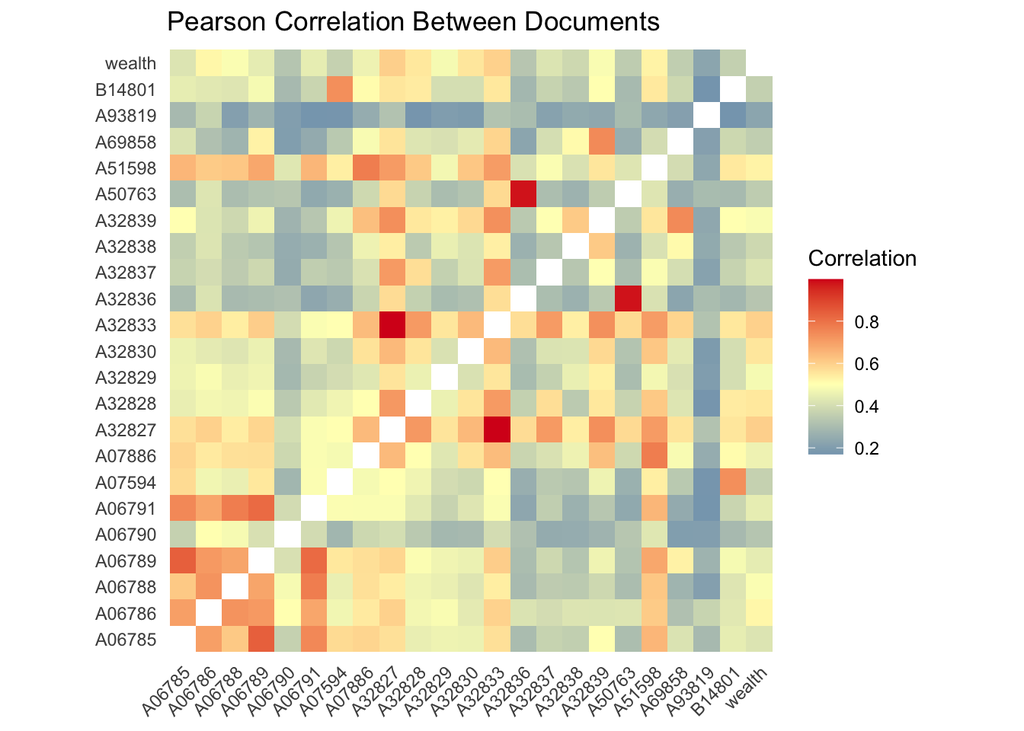

```r
ggplot(heat_df,
       aes(x = doc_j,
           y = doc_i,
           fill = r)) +
  geom_tile() +
  coord_fixed() +
  scale_fill_gradient2(
    low = "#2C7BB6",      # deep blue
    mid = "#FFFFBF",      # yellow
    high = "#D7191C",     # dark red
    midpoint = 0.5
  ) +
  labs(title = "Pearson Correlation Between Documents",
       x = NULL,
       y = NULL,
       fill = "Correlation") +
  theme_minimal() +
  theme(
    axis.text.x = element_text(angle = 45, hjust = 1),
    panel.grid = element_blank()
  )
```

APPROACH 3 - Syntactic complexity profile

Based on the similarity results, I selected two texts and implemented the Week 05 syntactic complexity framework. I measured sentence length, clause density, dependent clauses, coordination, and complex nominals to compare how the texts differ in grammatical structure.

```r
library(udpipe)
library(dplyr)
library(stringr)
```

```r
model <- udpipe_download_model(language = "english")
```

[output not shown]

[output not shown]

[output not shown]

[output not shown]

```r
ud_model <- udpipe_load_model(model$file_model)
```

```r
#Extract two texts

text_subset <- corpus_normalized %>%
  filter(doc_id %in% c("A32827", "A93819"))
```

```r
parsed <- udpipe_annotate(ud_model,
                          x = text_subset$text,
                          doc_id = text_subset$doc_id)

parsed_df <- as.data.frame(parsed)
```

```r
# MLS

sentence_lengths <- parsed_df %>%
  group_by(doc_id, sentence_id) %>%
  summarise(words = n(), .groups = "drop") %>%
  group_by(doc_id) %>%
  summarise(MLS = mean(words))
```

```r
# Clauses per sentence

clauses <- parsed_df %>%
  filter(upos == "VERB") %>%
  group_by(doc_id) %>%
  summarise(total_clauses = n())
```

```r
sentences <- parsed_df %>%
  distinct(doc_id, sentence_id) %>%
  count(doc_id, name = "total_sentences")
```

```r
cs_ratio <- clauses %>%
  left_join(sentences, by = "doc_id") %>%
  mutate(C_per_S = total_clauses / total_sentences)
```

```r
colnames(parsed_df)
```

```
##  [1] "doc_id"        "paragraph_id"  "sentence_id"   "sentence"
##  [5] "token_id"      "token"         "lemma"         "upos"
##  [9] "xpos"          "feats"         "head_token_id" "dep_rel"
## [13] "deps"          "misc"
```

```r
# Dependent Clauses

dependent_clauses <- parsed_df %>%
  filter(dep_rel %in% c("ccomp", "xcomp", "advcl", "acl")) %>%
  group_by(doc_id) %>%
  summarise(dep_clauses = n())
```

```r
# Coordination

coordination <- parsed_df %>%
  filter(dep_rel == "conj") %>%
  group_by(doc_id) %>%
  summarise(coordination = n())
```

```r
# Complex Nominals

complex_nominals <- parsed_df %>%
  filter(dep_rel %in% c("amod", "nmod", "compound")) %>%
  group_by(doc_id) %>%
  summarise(complex_nominals = n())
```

```r
summary_table <- sentence_lengths %>%
  left_join(cs_ratio, by = "doc_id") %>%
  left_join(dependent_clauses, by = "doc_id") %>%
  left_join(coordination, by = "doc_id") %>%
  left_join(complex_nominals, by = "doc_id")

summary_table
```

```
## # A tibble: 2 × 8
##   doc_id   MLS total_clauses total_sentences C_per_S dep_clauses coordination
##   <chr>  <dbl>         <int>           <int>   <dbl>       <int>        <int>
## 1 A32827  63.2          4978             910    5.47        2822         3402
## 2 A93819  60.2           247              50    4.94         112          203
## # ℹ 1 more variable: complex_nominals <int>
```

```r
# Extract example sentences
example_sentences <- parsed_df %>%
  group_by(doc_id, sentence_id) %>%
  summarise(sentence = paste(token, collapse = " "),
            .groups = "drop") %>%
  group_by(doc_id) %>%
  slice_sample(n = 1)
```

```r
dir.create("syntactic_results", showWarnings = FALSE)

write_csv(example_sentences,
          file.path("syntactic_results",
                    "syntactic_example_sentences.csv"))
```

```r
list.files("syntactic_results")
```

```
## [1] "syntactic_example_sentences.csv"
```

```r
sentences_full <- parsed_df %>%
  group_by(doc_id, sentence_id) %>%
  summarise(
    sentence = paste(token, collapse = " "),
    word_count = n(),
    .groups = "drop"
  )

example_A32827 <- sentences_full %>%
  filter(doc_id == "A32827") %>%
  slice_max(word_count, n = 1)

example_A93819 <- sentences_full %>%
  filter(doc_id == "A93819") %>%
  slice_min(word_count, n = 1)

example_sentences <- bind_rows(example_A32827,
                               example_A93819)

example_sentences
```

```
## # A tibble: 2 × 4
##   doc_id sentence_id sentence                                         word_count
##   <chr>        <int> <chr>                                                 <int>
## 1 A32827         417 i answer , those that make this objection , if …        343
## 2 A93819          45 1647 .                                                    2
```

```r
syntactic_measures <- summary_table %>%
  mutate(
    DC_per_S = dep_clauses / total_sentences,
    DC_per_C = dep_clauses / total_clauses,
    Coord_per_S = coordination / total_sentences,
    Coord_per_C = coordination / total_clauses,
    CN_per_S = complex_nominals / total_sentences,
    CN_per_C = complex_nominals / total_clauses
  ) %>%
  select(doc_id, MLS, C_per_S,
         DC_per_S, DC_per_C,
         Coord_per_S, Coord_per_C,
         CN_per_S, CN_per_C)
```

```r
syntactic_long <- syntactic_measures %>%
  pivot_longer(-doc_id,
               names_to = "measure",
               values_to = "value")
```

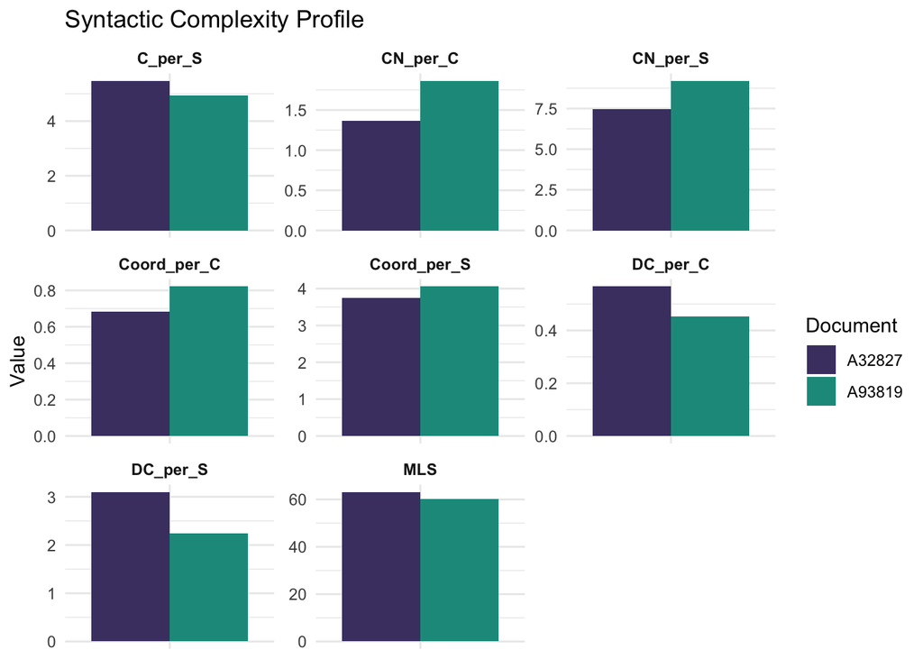

```r
ggplot(syntactic_long,
       aes(x = measure,
           y = value,
           fill = doc_id)) +
  geom_col(position = "dodge") +
  facet_wrap(~ measure, scales = "free") +
  scale_fill_manual(values = c("#4B3F72", "#1B998B")) +
  labs(title = "Syntactic Complexity Profile",
       x = NULL,
       y = "Value",
       fill = "Document") +
  theme_minimal() +
  theme(axis.text.x = element_blank(),
        strip.text = element_text(face = "bold"))
```

Central Analytical Question Do lexical similarity patterns within the corpus correspond to shared structural (syntactic) complexity, or are vocabulary and sentence structure operating independently?